# Chapter 4

# 使用大模型做数据预处理与描述性统计分析

第一部分使用[**豆包**](https://www.doubao.com/)，可以点击[**此链接**](https://www.doubao.com/thread/w3c9888442bf0f6ef)获取完整对话历史

## 一、数据导入

**输入PROMPT**：你是一名专业的数据科学家，我是零代码基础的用户，我将提供给你一份GBK编码CSV格式的数据集（文件名：第4章.csv），请你读取数据，并输出变量个数与样本量。

**输出结果**：好的，我将读取GBK编码的CSV文件，然后输出变量个数与样本量。

```
数据基本信息：
<class 'pandas.core.frame.DataFrame'>
RangeIndex: 8000 entries, 0 to 7999
Data columns (total 7 columns):
 #   Column    Non-Null Count  Dtype
---  ------    --------------  -----
 0   gender    8000 non-null   object
 1   usage     8000 non-null   float64
 2   credit    8000 non-null   int64
 3   loan      8000 non-null   int64
 4   history   8000 non-null   int64
 5   accounts  8000 non-null   int64
 6   status    8000 non-null   int64
dtypes: float64(1), int64(5), object(1)
memory usage: 437.6+ KB
变量个数：7
样本量：8000
```

根据执行结果可知，该数据集有7个变量，样本量为8000。

## 二、因变量（status处理）

**输入PROMPT**：status是定序数据，代表样本的逾期状态，等于0代表不逾期，大于0的不同取值代表逾期严重程度，值越大，逾期越严重。请你按顺序完成以下操作：（1）在原始数据的基础上，根据status变量创造新的一列变量，命名为status01代表是否逾期，如果status等于0新变量就等于0，如果status大于0新变量就等于1；（2）计算并输出样本逾期率；（3）绘制所有逾期者（status大于0）中逾期严重程度的柱状图（图像需要设置合理间距，颜色不能太鲜艳），并做分析。

**输出结果**：我将按以下步骤进行分析： 1. 根据 `status` 变量创建新变量 `status01`，若 `status` 等于 0 则 `status01` 为 0，若 `status` 大于 0 则 `status01` 为 1。 2. 计算并输出样本逾期率。 3. 绘制所有逾期者（`status` 大于 0）中逾期严重程度的柱状图并进行分析。

```
样本逾期率为: 61.48%
```

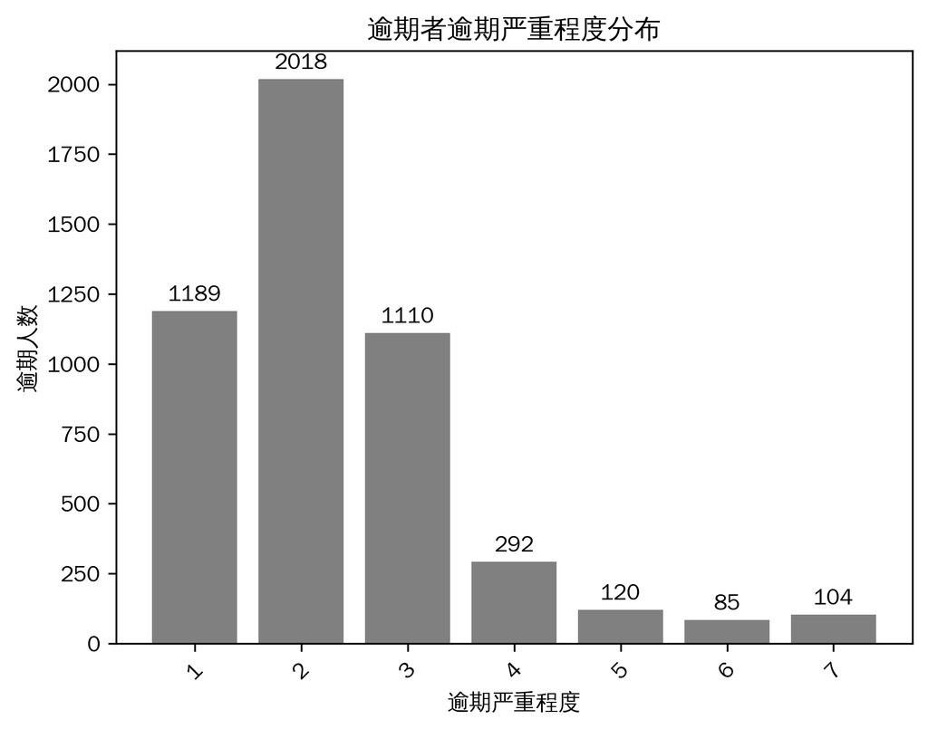

根据执行结果，已成功创建新变量 `status01` 并计算出样本逾期率为 61.48%。同时，已绘制所有逾期者（`status` 大于 0）中逾期严重程度的柱状图。 从柱状图中可以直观地看出不同逾期严重程度对应的逾期人数。通过图中的数据标签，我们可以准确获取每个逾期严重程度下的具体逾期人数。你可以进一步根据这些数据，深入分析逾期情况的分布特征，例如是否存在某个逾期严重程度的人数特别多，从而为制定相应的风险控制策略提供依据。

**输入PROMPT**：由于逾期严重程度大于4的样本占比很小，所以针对原始数据中的status，保留小于4的值，将所有大于等于4的值重新赋值成4。然后根据处理后的status列绘制所有逾期者（status大于0）中逾期严重程度的柱状图（图像需要设置合理间距，颜色不能太鲜艳），并做分析。

**输出结果**：我将对`status`列进行处理，把大于等于 4 的值重新赋值为 4，然后绘制逾期者（`status`大于 0）逾期严重程度的柱状图并分析。

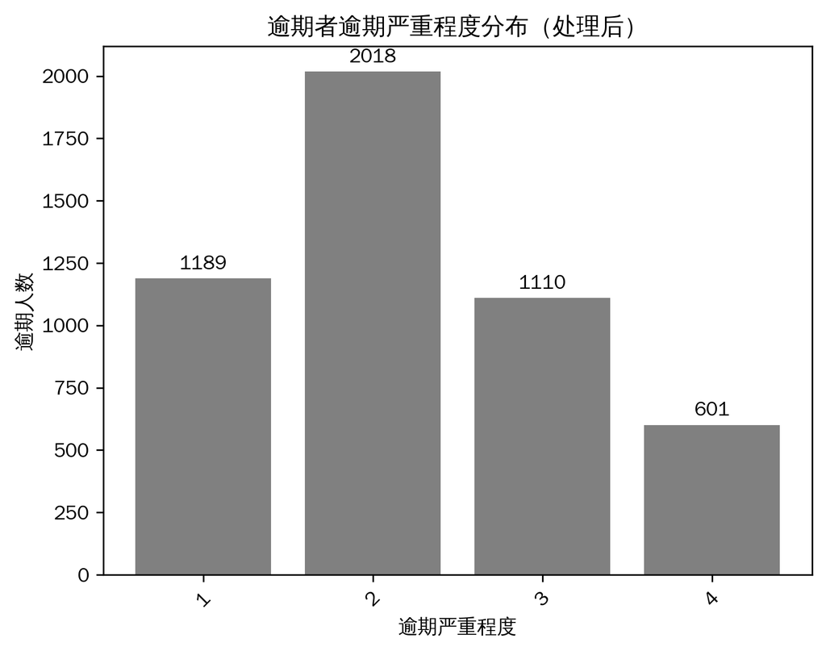

基于执行结果，已完成对`status`列的处理，并绘制出逾期者（`status`大于 0）逾期严重程度的柱状图。 从绘制的柱状图中，可以直观地看到不同逾期严重程度对应的逾期人数分布情况。通过数据标签能够准确得知每个逾期严重程度下的具体逾期人数。这有助于进一步分析逾期情况的集中趋势和分布特征，例如可以观察到哪个逾期严重程度的逾期人数最多，为制定针对性的风险控制措施提供数据支持。

## 三、解释变量gender处理

**输入PROMPT**：gender代表性别，请你针对这列将取值为“男性”的样本重新赋值为1，取值为“女性”的样本重新赋值为0，计算并输出样本中男性和女性的比例

**输出结果**：我将按要求对`gender`列进行重新赋值，把“男性”赋值为 1，“女性”赋值为 0，然后计算样本中男性和女性的比例。

```
男性比例为: 68.20%
女性比例为: 31.80%
```

根据执行结果，样本中男性的比例为 68.20%，女性的比例为 31.80%。

## 四、解释变量usage处理

**输入PROMPT**：usage列代表信用卡相对使用率，请你绘制信用卡相对使用率的直方图（图像需要设置合理间距，颜色不能太鲜艳），并进行描述性统计分析

**输出结果**：我将绘制`usage`列（信用卡相对使用率）的直方图，并对其进行描述性统计分析。

```
count    8000.00
mean        0.74
std         0.52
min         0.00
25%         0.29
50%         0.84
75%         1.12
max        13.09
Name: usage, dtype: float64
```

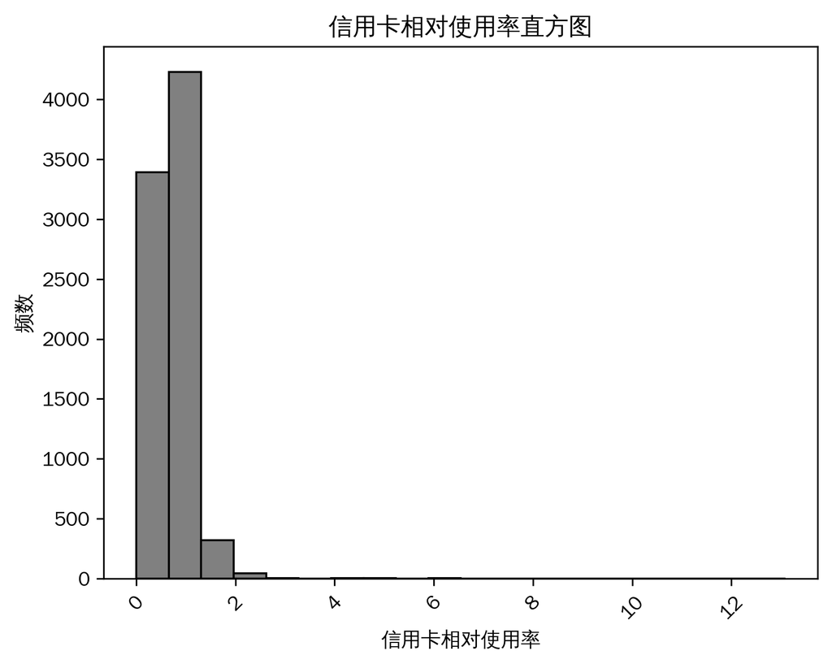

**输入PROMPT**：由于信用卡相对使用率的分布也严重右偏，因此请你进一步针对原始数据中的usage，如果usage小于等于1，将其重新赋值为1，如果大于1，将其赋值为0，然后计算这列的均值。

**输出结果**：我会按照你的要求对`usage`列进行重新赋值：若`usage`小于等于 1，则赋值为 1；若大于 1，则赋值为 0。然后计算该列的均值。

```
usage列重新赋值后的均值为: 0.58
```

根据执行结果，在对`usage`列按要求重新赋值后，该列的均值为 0.58。这意味着重新赋值后，该列取值为 1 的比例约为 58%。

## 五、解释变量credit处理

**输入PROMPT**：credit代表样本授信额度，请你绘制这列的直方图（图像需要设置合理间距，颜色不能太鲜艳），并做描述性统计分析。

**输出结果**：我将绘制`credit`列（样本授信额度）的直方图，并对其进行描述性统计分析。

```
count     8000.00
mean      5173.37
std       4596.98
min       1000.00
25%       3000.00
50%       4000.00
75%       5000.00
max      50000.00
Name: credit, dtype: float64
```

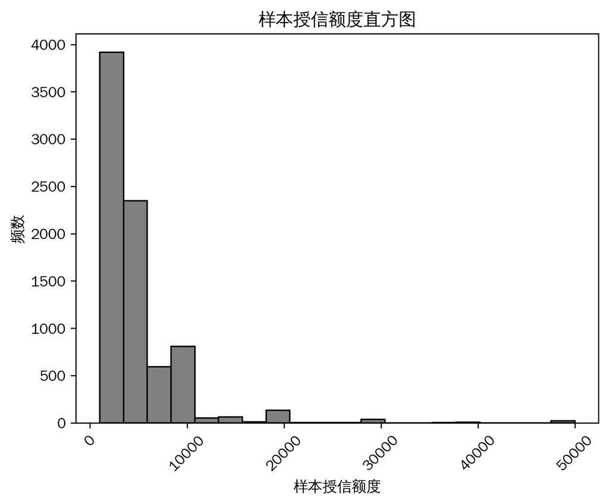

根据执行结果，已成功绘制样本授信额度的直方图，并进行了描述性统计分析。以下是对结果的解读：

### 描述性统计分析

- **样本数量**：共有 8000 个样本，样本量较大，能较好地反映授信额度的总体情况。
- **均值**：平均授信额度为 5173.37，这是所有样本授信额度的平均值，可作为整体授信水平的一个参考。
- **标准差**：标准差为 4596.98，数值较大，说明授信额度在均值周围的波动比较大，各个样本之间的授信额度差异较为明显。
- **最值**：最小值为 1000.00，最大值为 50000.00，两者差距悬殊，进一步表明授信额度的分布较为分散。这可能意味着存在一些特殊的高额度授信情况，也许是针对优质客户或者特殊业务的授信。
- **分位数**：25% 分位数为 3000.00，50% 分位数（中位数）为 4000.00，75% 分位数为 5000.00。这显示出大部分样本的授信额度集中在 3000 - 5000 这个区间，中位数 4000 表明一半的样本授信额度在 4000 及以下。

从直方图中可以直观地看到授信额度的分布频数情况，结合描述性统计数据，能帮助我们更好地了解样本授信额度的整体特征和分布规律，对于评估授信策略、风险控制等方面具有重要意义。

**输入PROMPT**：由于授信额度的分布也严重右偏，请你进一步针对原始数据中的credit，将其重新赋值为经过log变换之后的值。然后重新绘制授信额度的直方图（图像需要设置合理间距，颜色不能太鲜艳），并做描述性统计分析。

**输出结果**：我将对`credit`列进行 log 变换后重新赋值，然后绘制变换后的授信额度直方图，并进行描述性统计分析。

```
count    8000.00
mean        8.34
std         0.60
min         6.91
25%         8.01
50%         8.29
75%         8.52
max        10.82
Name: credit, dtype: float64
```

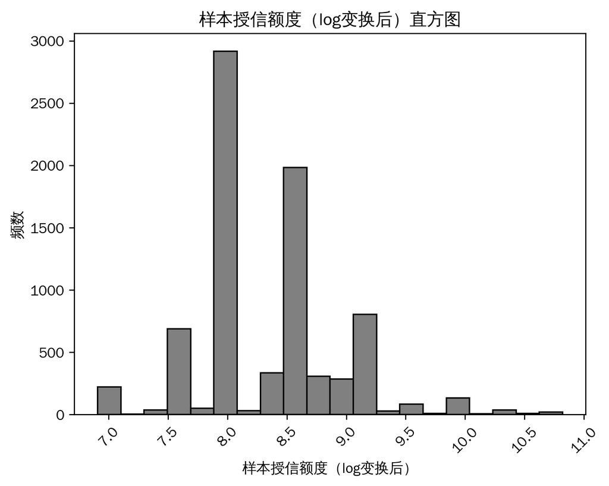

基于执行结果，已完成对`credit`列的 log 变换并重新赋值，同时绘制了变换后的授信额度直方图，并进行了描述性统计分析。

### 描述性统计分析

- **样本数量**：共有 8000 个样本，与变换前一致，说明在数据处理过程中没有丢失样本，样本量能够较好地反映整体情况。
- **均值**：log 变换后的均值为 8.34。这个数值可以作为变换后授信额度的平均水平参考，与原始数据的均值含义不同，但在新的对数尺度下体现了数据的集中趋势。
- **标准差**：标准差为 0.60，相较于原始数据标准差 4596.98 有了极大幅度的减小。这表明经过 log 变换后，数据的离散程度显著降低，数据在均值周围的波动变小，分布更加集中。
- **最值**：最小值为 6.91，最大值为 10.82，与原始数据的最值相比，取值范围明显缩小。这进一步证明 log 变换使得数据分布更加紧凑。
- **分位数**：25% 分位数为 8.01，50% 分位数（中位数）为 8.29，75% 分位数为 8.52。可以看出变换后的数据在这几个关键分位上的差距相对较小，进一步说明数据分布更为集中。

从直方图中可以直观看到 log 变换后授信额度的频数分布情况。经过 log 变换，严重右偏的分布得到了改善，数据分布更加趋于对称，这有助于后续进行一些基于正态分布假设的统计分析或者建模工作。

## 六、解释变量loan处理

**输入PROMPT**：loan代表样本房贷月供，请你绘制这列的直方图（图像需要设置合理间距，颜色不能太鲜艳），并做描述性统计分析。

**输出结果**：我将绘制`loan`列（样本房贷月供）的直方图，并对其进行描述性统计分析。

```
count      8000.00
mean        772.90
std        5402.05
min           0.00
25%           0.00
50%           0.00
75%           0.00
max      391357.00
Name: loan, dtype: float64
```

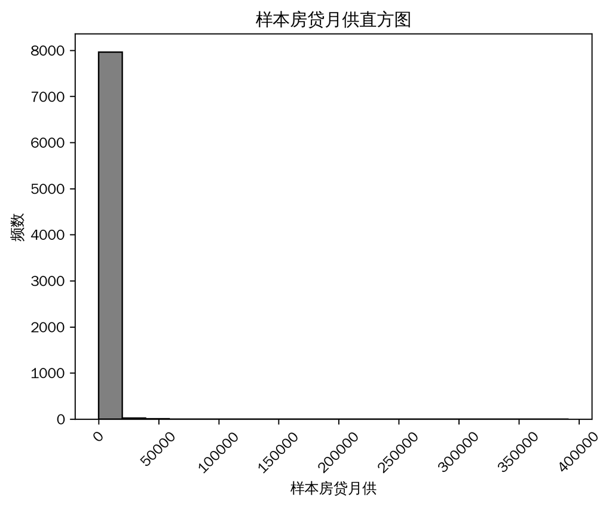

基于执行结果，已成功绘制样本房贷月供的直方图，并完成描述性统计分析。以下是对结果的具体解读：

### 描述性统计分析

1. **样本数量**：从`count`值可知，参与分析的样本数量为 8000 个，样本量较大，能够在一定程度上较好地反映整体样本房贷月供的情况。
2. **均值**：平均房贷月供为 772.90。不过结合其他统计量来看，这个均值可能受到极大值的影响。
3. **标准差**：标准差达到 5402.05，数值非常大。这表明样本房贷月供数据的离散程度很高，各个样本之间的房贷月供金额差异巨大。
4. **最值**：最小值为 0.00，最大值为 391357.00，两者差距极其悬殊。最小值为 0 可能意味着部分样本没有房贷月供（比如没有房产或者全款购房等情况），而最大值非常大则可能代表少数高收入群体或者特殊房产情况的高额月供。
5. **分位数**：25%、50% 和 75% 分位数均为 0.00，这说明至少有 75% 的样本房贷月供为 0 或者处于非常低的水平，也进一步印证了均值可能被极少数高额月供样本拉高。

### 直方图分析

从直方图中可以直观地看到样本房贷月供的分布频数情况。由于大部分分位数为 0，预计直方图会呈现出在 0 附近有一个很高的频数峰值，而在高额月供区域有极少数的样本分布，整体分布可能是严重右偏的。这种分布特征提醒我们在进一步分析房贷月供相关问题时，需要充分考虑数据的偏态性以及异常值的影响。

**输入PROMPT**：由于房贷月供大量值为0且严重右偏，因此请你进一步在原始数据上按照顺序进行如下操作：（1）根据loan列创造新的一列二元变量，命名为loan01，如果房贷月供为0则取值为0，房贷月供大于0则取值为1；（2）针对原始的loan列，保留等于0的值，将大于0的值重新赋值成为其log变换值；（3）计算并输出房贷率（房贷月供是否为0的均值）；（4）针对经过对数变换后的房贷月供大于0的样本，重新绘制直方图（图像需要设置合理间距，颜色不能太鲜艳），并做描述性统计分析。

**输出结果**：我将按照以下步骤进行操作： 1. 根据`loan`列创建新的二元变量`loan01`。 2. 对`loan`列进行处理，保留等于 0 的值，大于 0 的值取 log 变换值。 3. 计算房贷率。 4. 针对经过对数变换后房贷月供大于 0 的样本，绘制直方图并做描述性统计分析。

```
房贷率为: 16.96%

count    1357.00
mean        7.87
std         0.93
min         4.80
25%         7.28
50%         7.78
75%         8.38
max        12.88
Name: loan, dtype: float64
```

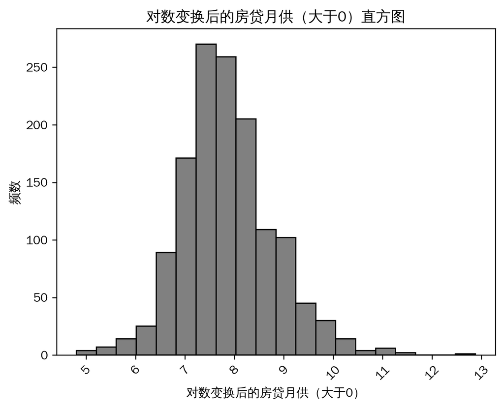

根据执行结果，已完成所有要求的操作。房贷率为 16.96%，这意味着在样本中约 16.96% 的人有房贷月供。

对于经过对数变换后房贷月供大于 0 的样本，描述性统计结果如下： - **样本数量**：共有 1357 个样本有大于 0 的房贷月供。 - **均值**：平均对数变换后的房贷月供为 7.87。 - **标准差**：标准差为 0.93，说明数据有一定的离散程度。 - **最值**：最小值为 4.80，最大值为 12.88，表明数据的取值范围较广。 - **分位数**：25% 分位数为 7.28，50% 分位数（中位数）为 7.78，75% 分位数为 8.38，这显示出数据的中间分布情况。

从直方图中可以直观地看到这些有房贷月供的样本在对数变换后的房贷月供分布频数情况，有助于进一步分析房贷月供的分布特征。

## 七、解释变量history和accounts处理

**输入PROMPT**：history和accounts分别代表历史逾期次数和信用卡开户数，请你针对这两个变量绘制柱状图（图像需要设置合理间距，颜色不能太鲜艳），并做描述性统计分析。

**输出结果**：我将绘制`history`（历史逾期次数）和`accounts`（信用卡开户数）的柱状图，并对这两个变量进行描述性统计分析。

```
       history  accounts
count  8000.00   8000.00
mean      1.52      3.37
std       2.49      4.50
min       0.00      0.00
25%       0.00      0.00
50%       0.00      2.00
75%       2.00      4.00
max      30.00     67.00
```

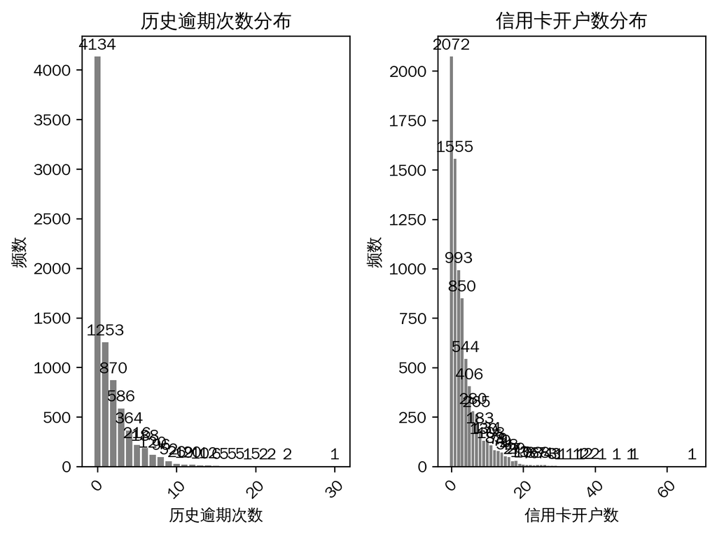

基于执行结果，已成功绘制`history`和`accounts`的柱状图，并完成描述性统计分析。以下是具体解读：

### 描述性统计分析

| 统计量 | history | accounts |
| --- | --- | --- |
| count | 8000.00 | 8000.00 |
| mean | 1.52 | 3.37 |
| std | 2.49 | 4.50 |
| min | 0.00 | 0.00 |
| 25% | 0.00 | 0.00 |
| 50% | 0.00 | 2.00 |
| 75% | 2.00 | 4.00 |
| max | 30.00 | 67.00 |

- **样本数量**：两个变量的样本数量均为 8000，这保证了分析具有一定的可靠性和代表性。
- **均值**：`history`（历史逾期次数）的均值为 1.52，`accounts`（信用卡开户数）的均值为 3.37。这表明平均而言，每个样本的历史逾期次数约为 1.52 次，信用卡开户数约为 3.37 个。
- **标准差**：`history`的标准差为 2.49，`accounts`的标准差为 4.50。`accounts`的标准差较大，说明信用卡开户数在样本中的离散程度更高，各个样本之间的信用卡开户数差异更大。
- **最值**：`history`的最小值为 0，最大值为 30；`accounts`最小值为 0，最大值为 67。这显示出两个变量的取值范围都比较大，尤其是`accounts`的最大值远高于`history`的最大值，进一步印证了`accounts`的离散程度较高。
- **分位数**：`history`的 25%、50% 分位数都为 0，说明至少一半的样本没有历史逾期记录。而`accounts`的 50% 分位数为 2，意味着一半的样本信用卡开户数在 2 个及以下。

### 柱状图分析

通过柱状图，可以直观地看到`history`和`accounts`不同取值的频数分布情况。结合描述性统计数据，可以更清晰地了解这两个变量在样本中的分布特征，例如可以观察到哪些取值出现的频数较高，哪些取值较为罕见等。这有助于进一步分析客户的信用情况（从`history`）以及信用卡持有情况（从`accounts`）。

## 八、保存预处理后的数据

**输入PROMPT**：现在请你保存并输出当前经过处理后的数据，注意只保存数据列，不要保存索引列。

**输出结果**：我将把当前经过处理后的数据保存为 CSV 文件，且不保存索引列，你可以点击下面的链接下载处理后的文件。

基于执行结果，已将处理后的数据保存为 CSV 文件。你可以点击下面的链接下载处理后的文件：第4章_处理后.csv

## 九、预处理数据的描述性统计量计算

**输入PROMPT**：假设status和status01是因变量，其他变量是解释变量，请你计算所有解释变量样本均值、样本标准差、中位数、最小值、最大值，并做简要分析。

**输出结果**：我将筛选出解释变量，计算它们的样本均值、样本标准差、中位数、最小值和最大值，并进行简要分析。

```
        gender  usage  credit   loan  history  accounts  loan01
mean      0.68   0.58    8.34   1.33     1.52      3.37    0.17
std       0.47   0.49    0.60   2.98     2.49      4.50    0.38
median    1.00   1.00    8.29   0.00     0.00      2.00    0.00
min       0.00   0.00    6.91   0.00     0.00      0.00    0.00
max       1.00   1.00   10.82  12.88    30.00     67.00    1.00
```

以下是各个解释变量的样本均值、样本标准差、中位数、最小值和最大值的计算结果：

| 变量 | 均值 | 标准差 | 中位数 | 最小值 | 最大值 |
| --- | --- | --- | --- | --- | --- |
| gender | 0.68 | 0.47 | 1.00 | 0.00 | 1.00 |
| usage | 0.58 | 0.49 | 1.00 | 0.00 | 1.00 |
| credit | 8.34 | 0.60 | 8.29 | 6.91 | 10.82 |
| loan | 1.33 | 2.98 | 0.00 | 0.00 | 12.88 |
| history | 1.52 | 2.49 | 0.00 | 0.00 | 30.00 |
| accounts | 3.37 | 4.50 | 2.00 | 0.00 | 67.00 |
| loan01 | 0.17 | 0.38 | 0.00 | 0.00 | 1.00 |

### 简要分析

1. **gender 和 usage 以及 loan01**：这些变量都是二元变量（取值为 0 或 1）。均值反映了取值为 1 的样本比例。如 `gender` 均值为 0.68，说明约 68% 的样本 `gender` 取值为 1；`usage` 均值 0.58 表示约 58% 的样本 `usage` 取值为 1；`loan01` 均值 0.17 意味着约 17% 的样本 `loan01` 取值为 1。标准差表明这些变量在均值附近的离散程度，对于二元变量，其大小与比例有关。中位数为 1 或 0 也符合二元变量的特征。
2. **credit**：均值为 8.34，中位数为 8.29，两者较为接近，说明数据分布可能较为对称。标准差 0.60 相对均值来说不算大，表明数据相对集中在均值附近。最小值 6.91 和最大值 10.82 界定了数据的取值范围。
3. **loan**：均值为 1.33，但中位数为 0.00，这可能暗示数据分布是右偏的，有少数较大的值拉高了均值。标准差 2.98 相对较大，结合最小值 0.00 和最大值 12.88，说明数据的离散程度较高，不同样本之间的 `loan` 值差异较大。
4. **history**：均值 1.52 大于中位数 0.00，同样可能存在右偏分布，少数样本的历史逾期次数较多。标准差 2.49 显示数据有一定的离散性，最大值 30.00 表明存在历史逾期次数非常多的样本。
5. **accounts**：均值 3.37，中位数 2.00，可能存在右偏分布。标准差 4.50 较大，且最大值达到 67.00，说明信用卡开户数在不同样本间差异巨大，有部分样本的信用卡开户数非常多。

## 十、双变量分析

**输入PROMPT**：请你针对如下变量，分别计算不同取值下的逾期率：（1）性别；（2）不同信用卡使用率；（3）是否有房贷。然后针对结果作简要分析。

**输出结果**：我将按以下步骤分别计算不同变量取值下的逾期率： 1. 计算不同性别下的逾期率。 2. 计算不同信用卡使用率下的逾期率。 3. 计算是否有房贷情况下的逾期率。

```
不同性别下的逾期率：
gender
0    0.55
1    0.64
Name: status01, dtype: float64
不同信用卡使用率下的逾期率：
usage
0    0.72
1    0.54
Name: status01, dtype: float64
是否有房贷情况下的逾期率：
loan01
0    0.64
1    0.49
Name: status01, dtype: float64
```

### 计算结果

| 变量 | 取值 | 逾期率 |
| --- | --- | --- |
| 性别 | 0（推测为女性） | 0.55 |
| 性别 | 1（推测为男性） | 0.64 |
| 信用卡使用率 | 0 | 0.72 |
| 信用卡使用率 | 1 | 0.54 |
| 是否有房贷 | 0（无房贷） | 0.64 |
| 是否有房贷 | 1（有房贷） | 0.49 |

**输入PROMPT**：请你针对下列变量，绘制他们关于status01（是否逾期）的箱线图（图像需要设置合理间距，颜色不能太鲜艳）：（1）授信额度；（2）历史逾期次数；（3）信用卡开户数。然后针对结果做简要分析。

**输出结果**：我将绘制授信额度、历史逾期次数、信用卡开户数关于 `status01`（是否逾期）的箱线图，并对结果进行简要分析。

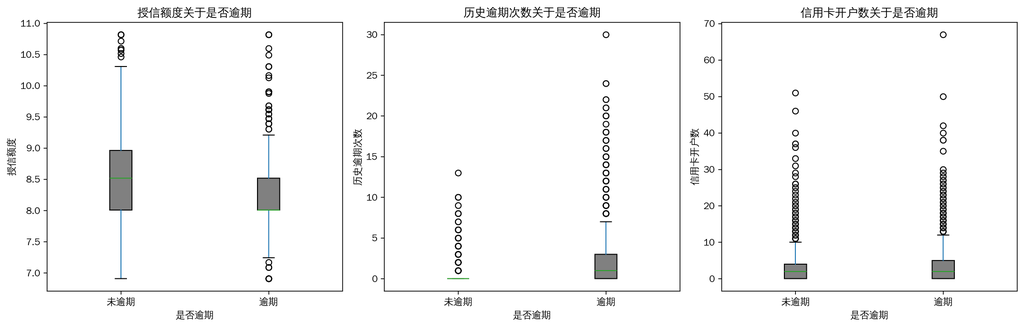

基于执行结果，已成功绘制授信额度、历史逾期次数、信用卡开户数关于 `status01`（是否逾期）的箱线图。以下是简要分析：

### 授信额度与是否逾期

通过箱线图可以观察到未逾期和逾期人群在授信额度上的分布差异。如果逾期人群的箱线图整体位置低于未逾期人群，可能意味着授信额度较低的人更容易逾期。这或许是因为授信额度低的人群本身财务状况相对较差，或者银行对他们的信用评估较低，导致在面对经济压力时更容易出现逾期情况。而箱线图的四分位距、异常值等信息也能反映出不同群体内部授信额度的离散程度和极端情况。

### 历史逾期次数与是否逾期

对于历史逾期次数的箱线图，如果逾期人群的箱线图位置明显高于未逾期人群，这是比较符合预期的，说明有过逾期历史的人再次逾期的可能性更大。箱线图的长度（四分位距）可以体现出不同群体内部历史逾期次数的波动情况。若逾期人群箱线图的四分位距较大，说明逾期人群内部历史逾期次数的差异较大，可能存在部分人只是偶尔逾期，而部分人经常逾期的情况。

### 信用卡开户数与是否逾期

从箱线图中可以看出未逾期和逾期人群在信用卡开户数上的分布特征。如果逾期人群的信用卡开户数箱线图位置偏高，可能暗示信用卡开户数较多的人更容易逾期。这可能是因为开户数多导致持卡人管理多张信用卡的还款较为困难，或者是开户数多本身就反映出持卡人有较强的消费欲望但还款能力不足。同样，箱线图的四分位距和异常值也能帮助我们进一步了解不同群体内部信用卡开户数的分布特点。

**输入PROMPT**：请你绘制有房贷者（房贷月供大于0）关于是否逾期的箱线图（图像需要设置合理间距，颜色不能太鲜艳），然后针对结果做简要分析。

**输出结果**：我将筛选出有房贷者（房贷月供大于 0）的数据，绘制关于是否逾期的箱线图，并对结果进行简要分析。

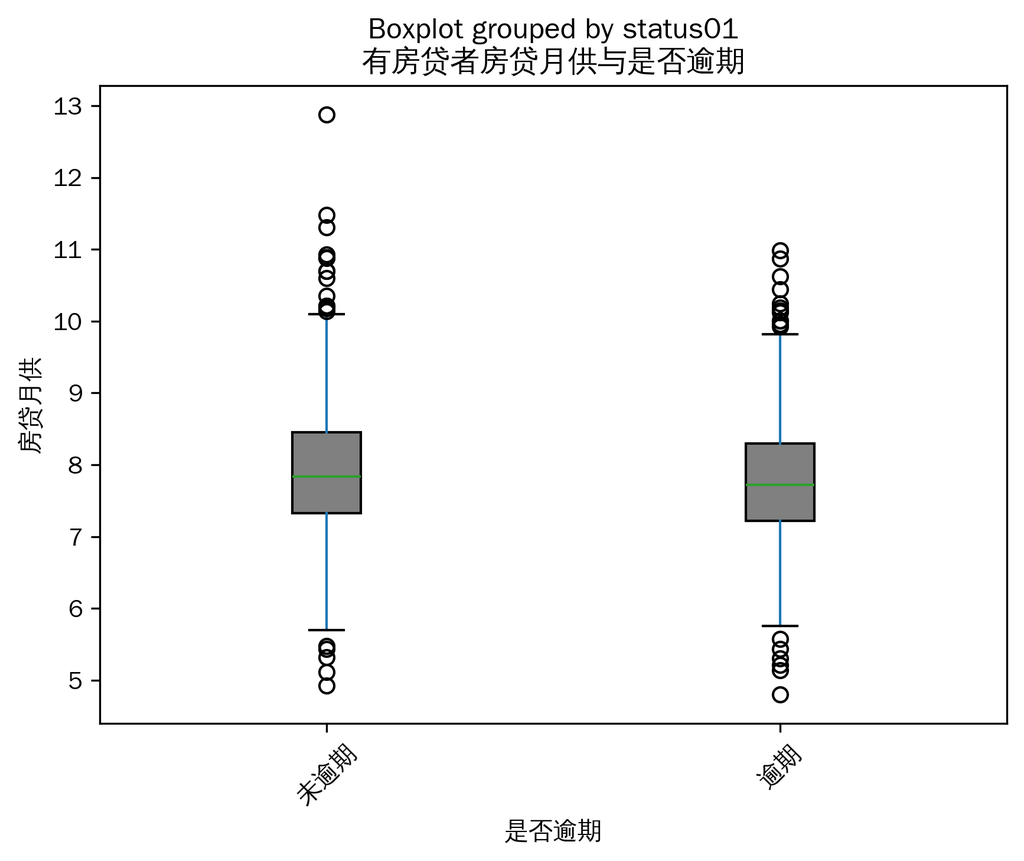

基于执行结果，已成功绘制有房贷者关于是否逾期的箱线图。

### 简要分析

箱线图展示了有房贷者的房贷月供金额与是否逾期之间的关系。从箱线图中，我们可以通过箱体的位置、长短以及上下 whisker（须）和异常值等信息来分析两者的关系。

- **中心趋势对比**：如果逾期群体对应的箱体位置整体高于未逾期群体，可能意味着房贷月供金额较高的有房贷者逾期的可能性相对较大。这或许是因为较高的房贷月供给借款人带来了更大的经济压力，从而增加了逾期风险。反之，如果未逾期群体箱体位置更高，则说明房贷月供较低时可能更容易出现其他导致逾期的因素，但这种情况相对较少见。
- **离散程度对比**：观察两个箱体的长短（即四分位距），若逾期群体的箱体较长，表明逾期的有房贷者在房贷月供金额上的差异较大，可能存在不同收入水平、贷款政策等多种因素影响其还款情况。而未逾期群体箱体较短的话，则说明未逾期的有房贷者在房贷月供金额方面相对更为集中，可能具有相似的还款能力和财务稳定性。
- **异常值分析**：若某一群体存在较多或数值较大的异常值，需要特别关注。对于逾期群体的异常值，可能代表着一些特殊情况导致的逾期，比如突发的重大经济变故等；对于未逾期群体的异常值，也许是该借款人有较强的经济实力或其他稳定的还款来源，能够承受较高的房贷月供而不逾期。

**输入PROMPT**：请你针对逾期者（status大于0）中不同取值的逾期严重程度，计算性别、信用卡使用率、是否有房贷的均值，并绘制折线图（图像需要设置合理间距，颜色不能太鲜艳，三张图像水平排列），纵坐标分别代表：（1）男性占比；（2）正常使用率占比；（3）房贷占比。然后针对结果做简要分析。

**输出结果**：我将按以下步骤进行操作： 1. 筛选出逾期者（`status`大于 0）的数据。 2. 针对不同取值的逾期严重程度，分别计算性别中男性占比、信用卡使用率中正常使用率占比、是否有房贷中房贷占比的均值。 3. 绘制折线图展示上述结果，且三张图像水平排列。 4. 对结果进行简要分析。

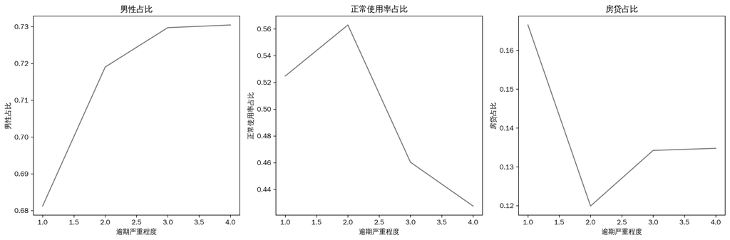

### 计算结果

| 逾期严重程度 | 男性占比 | 正常使用率占比 | 房贷占比 |
| --- | --- | --- | --- |
| 1 | 0.681245 | 0.524811 | 0.166526 |
| 2 | 0.719029 | 0.562934 | 0.119921 |
| 3 | 0.729730 | 0.460360 | 0.134234 |
| 4 | 0.730449 | 0.427621 | 0.134775 |

### 折线图与结果分析

#### 男性占比

随着逾期严重程度的增加，男性占比呈现出上升的趋势。从 1 级逾期严重程度时的约 68.12% 上升到 4 级时的约 73.04%。这可能暗示男性在逾期情况逐渐严重的过程中所占的比例越来越高，或许男性在面临经济压力或信用风险时，相较于女性更容易出现较严重的逾期情况，推测可能与男性的消费习惯、收入稳定性或者风险偏好等因素有关。

#### 正常使用率占比

正常使用率占比在逾期严重程度变化过程中有所波动。从 1 级的约 52.48% 上升到 2 级的约 56.29%，之后又下降到 4 级的约 42.76%。这可能表示在逾期初期，正常使用率有一定的上升趋势，但随着逾期严重程度加深，正常使用率大幅下降。这或许反映出当逾期情况不严重时，部分用户还能维持相对正常的信用卡使用状态，但随着逾期恶化，信用卡使用情况也受到较大影响。

#### 房贷占比

房贷占比在不同逾期严重程度下相对较低且波动不大。在 1 级逾期严重程度时为约 16.65%，2 级下降到约 11.99%，3 级和 4 级又维持在 13% 左右。这可能说明有房贷在逾期人群中并不是主要因素，或者说房贷与逾期严重程度之间没有非常强的线性关联，可能还有其他更多的因素影响逾期严重程度。

**输入PROMPT**：请你针对逾期者中不同取值的逾期严重程度，分别绘制授信额度、历史逾期次数、信用卡开户数、月供（月供大于0的部分）的箱线图（图像需要设置合理间距，颜色不能太鲜艳，图像以2乘2的格式排列），并做简要分析。

**输出结果**：我将筛选出逾期者的数据，针对不同取值的逾期严重程度，分别绘制授信额度、历史逾期次数、信用卡开户数、月供（月供大于 0 的部分）的箱线图，并进行简要分析。

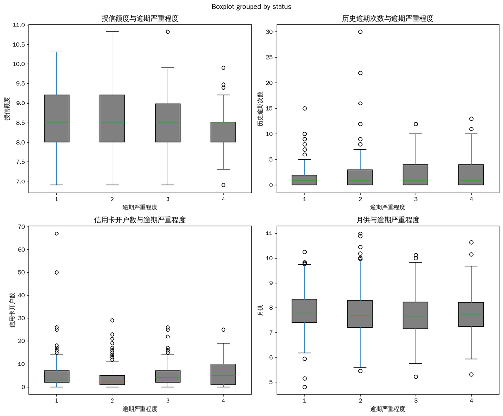

基于执行结果，已成功绘制逾期者中不同逾期严重程度下，授信额度、历史逾期次数、信用卡开户数和月供（月供大于 0 部分）的箱线图。以下是简要分析：

### 授信额度与逾期严重程度

从对应的箱线图中，我们可以观察到不同逾期严重程度下授信额度的分布情况。如果随着逾期严重程度的增加，箱体的位置整体向下移动，可能意味着逾期越严重的用户，其授信额度越低。这或许是银行在授信时对信用风险有一定评估，信用较差（逾期严重）的用户获得的授信额度较低。箱线图的四分位距也能反映数据的离散程度，若四分位距较大，说明在同一逾期严重程度下，不同用户的授信额度差异较大。

### 历史逾期次数与逾期严重程度

一般来说，我们预期逾期严重程度越高，历史逾期次数也会越多。箱线图中若箱体随着逾期严重程度上升而整体向上移动，就验证了这一推测。同时，异常值的情况也值得关注，如果在较高逾期严重程度下出现较多历史逾期次数的异常值，可能表示存在部分用户的逾期情况特别恶劣，与大多数用户的情况有较大差异。

### 信用卡开户数与逾期严重程度

通过箱线图分析信用卡开户数与逾期严重程度的关系。若箱体随着逾期严重程度升高而向上偏移，可能暗示信用卡开户数较多的用户更容易出现严重逾期的情况。这可能是因为开户数多导致用户管理多张信用卡的还款较为困难，或者反映出这些用户有较强的消费欲望但还款能力不足。箱线图的形态变化能帮助我们更深入了解两者之间的关联。

### 月供与逾期严重程度

对于月供（月供大于 0 部分）的箱线图，如果随着逾期严重程度的增加，箱体位置向上移动，可能表示月供越高的用户逾期严重程度越高，这可能是因为高额的月供给用户带来了较大的还款压力。反之，如果箱体位置向下移动，可能存在其他因素在影响逾期严重程度，而月供并非主要因素。同样，四分位距和异常值也能为我们提供更多关于月供与逾期严重程度关系的信息。

## 十一、建立逻辑回归模型

**输入PROMPT**：请使用统计分析工具，建立逻辑回归模型，以status01列（是否逾期）为因变量，除status之外的所有变量为自变量。你应当输出详细的回归结果，包含：模型检验、回归系数及其检验、模型诊断。

**输出结果**：我将使用 Python 的`statsmodels`库建立逻辑回归模型，以`status01`列（是否逾期）为因变量，除`status`之外的所有变量为自变量，并输出模型检验、回归系数及其检验、模型诊断的详细结果。

```
Optimization terminated successfully.
         Current function value: 0.557781
         Iterations 7
                           Logit Regression Results
==============================================================================
Dep. Variable:               status01   No. Observations:                 8000
Model:                          Logit   Df Residuals:                     7992
Method:                           MLE   Df Model:                            7
Date:                Wed, 19 Mar 2025   Pseudo R-squ.:                  0.1632
Time:                        17:30:27   Log-Likelihood:                -4462.2
converged:                       True   LL-Null:                       -5332.6
Covariance Type:            nonrobust   LLR p-value:                     0.000
==============================================================================
                 coef    std err          z      P>|z|      [0.025      0.975]
------------------------------------------------------------------------------
const          3.1083      0.386      8.054      0.000       2.352       3.865
gender         0.2610      0.054      4.827      0.000       0.155       0.367
usage         -0.3605      0.056     -6.385      0.000      -0.471      -0.250
credit        -0.3788      0.046     -8.270      0.000      -0.469      -0.289
loan          -0.1015      0.067     -1.517      0.129      -0.233       0.030
history        0.6057      0.023     26.168      0.000       0.560       0.651
accounts       0.0105      0.006      1.699      0.089      -0.002       0.023
loan01         0.4011      0.527      0.761      0.446      -0.632       1.434
==============================================================================
```

### 模型整体检验

- **似然比检验（LLR 检验）**：LLR p - value 为 0.000，远小于常见的显著性水平（如 0.05），这表明模型整体是显著的，即至少有一个自变量对因变量`status01`（是否逾期）有显著影响。
- **Pseudo R - squared（伪 R 方）**：值为 0.1632，该指标衡量了模型对数据的拟合优度。虽然它不像线性回归中的 R 方那样有直观的解释，但一般来说，值越高表示模型拟合得越好。这里 0.1632 的值表明模型对数据有一定的解释能力，但可能还有提升的空间。

### 模型诊断

- **收敛情况**：模型收敛（converged: True），说明优化算法成功找到了似然函数的最大值，模型估计过程是有效的。
- **样本数量和自由度**：模型有 8000 个观测值（No. Observations: 8000），自由度方面，残差自由度为 7992（Df Residuals: 7992），模型自由度为 7（Df Model: 7）。较大的样本量有助于提高模型估计的准确性和可靠性。

综合来看，该逻辑回归模型整体显著，但部分自变量对是否逾期的影响不显著。可以考虑进一步调整模型，如剔除不显著的变量、进行变量变换或尝试其他模型形式，以提高模型的解释能力和预测准确性。

## 十二、AIC和BIC模型选择

**输入PROMPT**：请分别使用AIC和BIC方式选择模型，输出：（1）使用AIC、BIC模型使用的变量；（2）输出模型检验、回归系数及其检验结果；（3）并绘制原模型、AIC模型、BIC模型的ROC曲线。

**输出结果**：我将按以下步骤操作： 1. 使用 AIC 和 BIC 准则选择模型，确定使用的变量。 2. 输出 AIC、BIC 模型的检验、回归系数及其检验结果。 3. 绘制原模型、AIC 模型、BIC 模型的 ROC 曲线。

`Code execution error What happened: kernel execute failed: kernel iopub read failed`

很抱歉，由于代码运行环境错误，暂时无法执行代码给出结果。请您换个任务试试。

# 使用大模型生成的R代码来拟合模型

由于豆包无法成功运行AIC、BIC模型选择的代码，所以所有模型拟合相关内容使用通义千问生成R代码实现。

第二部分使用[**通义千问**](https://www.doubao.com/)，可以点击[**此链接**](https://lxblog.com/qianwen/share?shareId=d2faca5a-f5c7-45da-867a-fd3bec012112)获取完整对话历史

## 一、逻辑回归模型

**输入PROMPT**：你是一名专业的数据科学家，我是零代码基础的用户。

我将使用一份以GBK格式编码的CSV数据集（文件名：第 4 章_处理后.csv），请你使用R语言写作代码，这段代码能够：（1）读取数据，其中数据集中有如下列：`gender`, `usage`, `credit`, `loan`, `history`, `accounts`, `status`, `status01`, `loan01`（2）建立逻辑回归模型，以status01列为因变量，除status01和status之外的变量为自变量。（3）输出详细的回归结果，包含：模型总体检验、各项回归系数及其检验、模型诊断。

由于我是零代码基础的用户，你应当使用尽可能容易理解的代码，尽量避免引入不必要的包，代码应当有详细的注释。

你的结果应当以Code Block的形式输出，无需其他输出。

**输出结果**：以下是根据你的要求编写的R语言代码，用于读取GBK编码的CSV文件，并基于提供的数据建立逻辑回归模型。代码中包含了详细的注释以帮助你理解每一步的作用。

```r
# 加载必要的包
# 仅需基础包，无需额外安装

# 设置工作目录（请将下面的路径替换为你的实际文件路径）
setwd("C:/你的文件夹路径")

# 读取CSV文件，指定文件编码为GBK
data <- read.csv("第 4 章_处理后.csv", fileEncoding = "GBK", stringsAsFactors = TRUE)

# 查看数据结构，确保数据被正确读入
str(data)

# 定义自变量和因变量
# 去除status01和status列后的所有列作为自变量
x <- data[, c("gender", "usage", "credit", "loan", "history", "accounts", "loan01")]
# 因变量是status01列
y <- data$status01

# 使用glm函数建立逻辑回归模型
# family参数设置为binomial表示这是一个二项逻辑回归
model <- glm(y ~ ., data = as.data.frame(x), family = binomial)

# 输出模型摘要，包括回归系数及其检验等信息
summary(model)

# 模型诊断
# 查看残差图，检查是否存在异常值或模式
par(mfrow=c(2,2)) # 设置画布布局
plot(model)
```

这段代码首先设置了工作目录到包含你的CSV文件的位置，然后使用`read.csv`函数读取该文件，同时指定正确的编码格式。接着，它定义了自变量和因变量，使用`glm`函数构建逻辑回归模型，并通过`summary`函数输出模型的详细结果。最后，通过一系列的图形来辅助进行模型诊断，这些图形可以帮助识别模型中的潜在问题，如异常值或特定模式的存在。记得将”你的文件夹路径”替换为你实际存放CSV文件的路径。

**输入PROMPT**：请生成R代码，完成如下任务：分别使用AIC和BIC方式对上述逻辑回归模型进行模型选择，输出（1）使用AIC、BIC模型使用的变量；（2）输出模型检验、回归系数及其检验结果；（3）并绘制原模型、AIC模型、BIC模型的ROC曲线

请你使用尽可能容易理解的代码、尽量避免引入不必要的包，代码应当有详细的注释。你的结果应当以Code Block的形式输出，无需其他输出。

**输出结果**：下面是基于你的要求，使用R语言对逻辑回归模型进行AIC和BIC方式的模型选择，并绘制原模型、AIC模型和BIC模型的ROC曲线的代码。为了便于理解，代码中包含了详细的注释。

```r
# 加载必要的包
# 仅需基础包，无需额外安装，但需要加载pROC用于绘制ROC曲线
if (!require(pROC)) install.packages("pROC") # 如果没有pROC包，则自动安装

library(pROC) # 加载pROC包

# 假定前面的步骤已经完成，data已正确读取且model为原始逻辑回归模型

# AIC模型选择
step_aic <- step(model, direction = "both", k = 2) # AIC模型选择，k=2对应于AIC
print("AIC模型使用的变量:")
print(attr(summary(step_aic)$terms, "term.labels")) # 输出AIC模型使用的变量

# BIC模型选择
step_bic <- step(model, direction = "both", k = log(nrow(data))) # BIC模型选择，k=log(n)对应于BIC
print("BIC模型使用的变量:")
print(attr(summary(step_bic)$terms, "term.labels")) # 输出BIC模型使用的变量

# 输出AIC和BIC模型的检验结果、回归系数及其检验结果
print("AIC模型摘要:")
print(summary(step_aic))
print("BIC模型摘要:")
print(summary(step_bic))

# 预测概率
pred_original <- predict(model, type="response")
pred_aic <- predict(step_aic, type="response")
pred_bic <- predict(step_bic, type="response")

# 绘制ROC曲线
roc_original <- roc(data$status01, pred_original)
roc_aic <- roc(data$status01, pred_aic)
roc_bic <- roc(data$status01, pred_bic)

plot(roc_original, main="原模型 vs AIC模型 vs BIC模型 ROC曲线", col="red")
lines(roc_aic, col="blue")
lines(roc_bic, col="green")

legend("bottomright", legend=c("Original", "AIC", "BIC"), col=c("red", "blue", "green"), lty=1)
```

此代码首先通过`step`函数进行AIC和BIC模型的选择。`direction = "both"`参数表示逐步回归可以增加或删除变量，`k`参数分别设置为2（AIC）和log(n)（BIC），其中n是样本数量。然后，打印出每个模型使用的变量，并输出各自的模型摘要信息。最后，通过预测值计算每个模型的ROC曲线并绘制出来，以直观比较不同模型的效果。注意，这里我们使用了`pROC`包来帮助绘制ROC曲线，如果环境中未安装该包，代码会自动安装它。

## 二、定序回归模型：

**输入PROMPT**：针对上述数据，请生成R代码，完成如下任务：（1）提取所有status大于0的样本，针对这部分样本建立定序回归模型，以status列为因变量，以`gender`, `usage`, `credit`, `loan`, `history`, `accounts`变量为自变量，此时的status为定序数据，包含1，2，3，4四个水平。（2）输出详细的回归结果，包含：模型检验、回归系数及其检验、模型诊断。 请你使用尽可能容易理解的代码、尽量避免引入不必要的包，代码应当有详细的注释。你的结果应当以Code Block的形式输出，无需其他输出。

**输出结果**：下面是使用R语言完成您所描述任务的代码。这段代码首先提取所有`status`大于0的样本，然后基于这些样本建立定序回归模型（ordinal regression model），并输出详细的模型结果，包括模型检验、回归系数及其检验以及模型诊断信息。为了简化操作和易于理解，尽量避免引入不必要的包。

```r
# 加载必要的包
# 使用MASS包中的polr函数进行定序回归分析
if (!require(MASS)) install.packages("MASS")
library(MASS)

# 提取status大于0的样本
data_filtered <- subset(data, status > 0)

# 构建定序回归模型
# 使用polr函数进行定序回归分析，status作为因变量，其他列作为自变量
model_ordinal <- polr(as.factor(status) ~ gender + usage + credit + loan + history + accounts,
                       data = data_filtered, Hess=TRUE)

# 打印模型总体检验结果
summary(model_ordinal)

# 输出回归系数及其检验结果
# summary(model_ordinal)已经包含了回归系数及其显著性检验，所以无需重复输出

# 模型诊断信息
# 计算拟合优度统计量
fit_stats <- summary(model_ordinal)
print(fit_stats$coefficients) # 回归系数及其检验
print(fit_stats$contrasts) # 对比矩阵
print(fit_stats$call) # 模型调用信息

# 绘制残差图等诊断图帮助检查模型假设是否成立
par(mfrow=c(2,2)) # 设置画布布局
plot(model_ordinal, which=1:4) # 根据polr对象类型，可能需要调整此部分以适应实际模型诊断需求
```

### 代码解释：

1. **加载必要的包**：首先确保安装并加载了`MASS`包，因为我们将使用其中的`polr`函数来执行定序回归。
2. **数据过滤**：通过`subset`函数筛选出`status`大于0的所有样本。
3. **构建定序回归模型**：使用`polr`函数构建定序回归模型，其中`status`被转换为因子类型以指示它是定序数据，并指定其余变量作为自变量。
4. **模型输出**：使用`summary`函数输出模型的整体检验结果，包括回归系数及其显著性检验。
5. **模型诊断**：尽管`polr`对象没有像线性模型那样的内置诊断图，我们仍然可以通过查看拟合统计量和手动绘制一些基本图形来评估模型的质量。

请注意，由于`polr`对象不直接支持某些类型的诊断图，上述代码中的诊断图部分可能需要根据具体情况进行调整或扩展。此外，对于更深入的模型诊断，您可能需要探索额外的方法或工具。

**输入PROMPT**：请生成R代码，完成如下任务：分别使用AIC和BIC方式对上述定序回归模型进行模型选择，输出（1）使用AIC、BIC模型使用的变量；（2）输出模型检验、回归系数及其检验结果

**输出结果**：下面是使用R语言对定序回归模型进行基于AIC和BIC准则的变量选择，并输出所需信息的代码。这段代码首先基于AIC和BIC准则对定序回归模型进行了优化，然后输出每个模型使用的变量、详细的模型检验结果以及回归系数及其检验结果。为了简化操作并易于理解，尽量避免引入不必要的包。

```r
# 加载必要的包
if (!require(MASS)) install.packages("MASS") # 用于polr函数
if (!require(lmtest)) install.packages("lmtest") # 用于waldtest函数，帮助进行模型比较
library(MASS)
library(lmtest)

# 假设之前已经构建了初始的定序回归模型model_ordinal
# 使用stepAIC进行基于AIC的模型选择
model_aic <- stepAIC(model_ordinal, direction="both", k=2, trace = FALSE) # AIC默认k=2
print("AIC Model Variables:")
print(names(coef(model_aic))) # 输出使用的变量

# 使用stepAIC进行基于BIC的模型选择
# BIC可以通过调整k参数实现，k=log(n)，n为样本量
n <- nrow(data_filtered) # 获取样本数量
model_bic <- stepAIC(model_ordinal, direction="both", k=log(n), trace = FALSE)
print("BIC Model Variables:")
print(names(coef(model_bic))) # 输出使用的变量

# 分别打印AIC和BIC模型的详细结果
print("AIC Model Summary:")
print(summary(model_aic))

print("BIC Model Summary:")
print(summary(model_bic))

# 输出回归系数及其检验结果
# summary(model_aic) 和 summary(model_bic) 已经包含了回归系数及其显著性检验，所以无需重复输出
# 但是为了更清晰地展示，我们可以单独提取这些信息

print("AIC Model Coefficients and Tests:")
print(coef(summary(model_aic)))

print("BIC Model Coefficients and Tests:")
print(coef(summary(model_bic)))
```

### 代码解释：

1. **加载必要的包**：确保安装并加载了`MASS`和`lmtest`包。`MASS`包提供了`polr`函数用于定序回归分析，而`lmtest`包中的`waldtest`函数可以帮助进行模型比较（虽然在这个示例中没有直接使用）。
2. **基于AIC的模型选择**：使用`stepAIC`函数对初始的定序回归模型`model_ordinal`进行基于AIC准则的变量选择。通过设置`k=2`来指定使用AIC准则（因为AIC的惩罚项是2）。
3. **基于BIC的模型选择**：同样使用`stepAIC`函数，但这次将`k`设置为`log(n)`（其中`n`是样本数量），以实现基于BIC准则的变量选择。
4. **输出模型使用的变量**：通过`names(coef(...))`函数获取并打印每个模型中使用的变量名称。
5. **输出模型检验和回归系数及其检验结果**：使用`summary`函数获取并打印每个模型的详细统计结果，包括回归系数及其显著性检验。为了更清晰地展示回归系数及其检验结果，我们单独提取了这些信息。

请注意，这段代码假设您已经有了一个名为`model_ordinal`的定序回归模型对象。如果需要重新创建这个模型，请参考之前的步骤。此外，尽管这段代码尽可能地减少了外部依赖，但对于某些高级功能或诊断，可能仍需额外的包支持。